# P3.5-B Benchmark: Stage 2 vs gold + RummaGEO head-to-head

# P3.5-B benchmark report

Subset: 15 GSE curati (P3 fixture mini), classificati Stage 1+2 con gpt-5.5. Gold: `trtctr_EP` xlsx (binary normalizzato: treated/control/NA).

## 1. Stage 2 binary accuracy

**N (escluso NA): 197** | accuracy: **75.1%** | sensitivity: 74.8% | specificity: 75.7% | F1: 0.790

### Confusion matrix (rows = simulomicsr predicted, cols = gold)

```
##          gold
## predicted control treated
##   control      56      31
##   treated      18      92
```

### Breakdown per design_kind

Binary accuracy per design_kind (ordinata per accuracy)

| design_kind | n | accuracy | sensitivity | specificity | f1 |
| --- | --- | --- | --- | --- | --- |
| time_course | 21 | 1.000 | 1.000 | 1.000 | 1.000 |
| treatment_vs_vehicle | 12 | 1.000 | 1.000 | 1.000 | 1.000 |
| knockdown_panel | 5 | 1.000 | 1.000 | 1.000 | 1.000 |
| dose_response | 21 | 0.857 | 0.938 | 0.600 | 0.909 |
| factorial | 32 | 0.781 | 0.737 | 0.846 | 0.800 |
| multi_arm_treatment | 94 | 0.660 | 0.638 | 0.694 | 0.698 |
| treatment_vs_untreated | 12 | 0.417 | 0.429 | 0.400 | 0.462 |

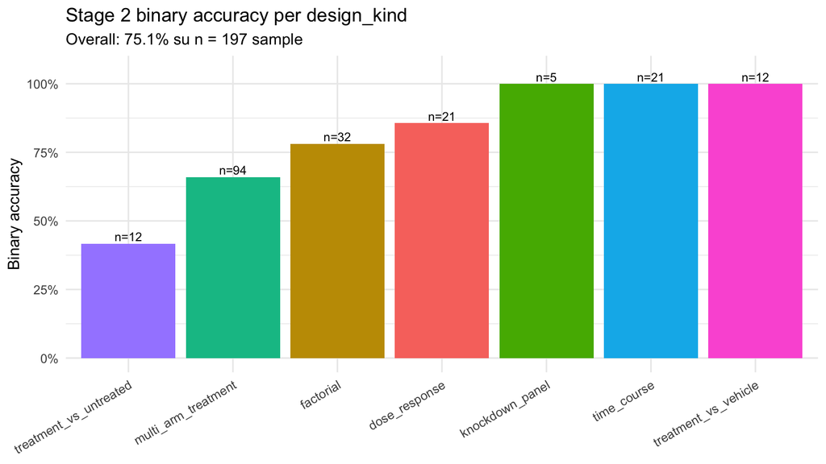

### Note investigative

**ATTENZIONE: design_kind con accuracy < 50%:**

- `treatment_vs_untreated` (n=12, accuracy=41.7%) – sotto il casuale, possibile role inversion. Da investigare in P3.5-A scaled benchmark.

## 2. Granularity disagreement enumeration

simulomicsr produce `design_role` valori che il gold binary non distingue. Questi NON sono errori – sono valore aggiunto del classificatore design-aware.

**Granularity flagged: 22 sample** su 219 totali nel join (10.0% del subset)

### Esempi rappresentativi

Un esempio per granularity_kind

| series_id | geo_accession | design_role | predicted_binary | gold_binary | granularity_kind |
| --- | --- | --- | --- | --- | --- |
| GSE200037 | GSM6005152 | baseline_t0 | control | control | baseline_t0 |
| GSE155528 | GSM4705774 | secondary_arm | treated | control | secondary_arm |

## 3. Anchor coverage cross-studio (intra-15)

**Anchor unici totali:** 47. **Anchor in N>=2 GSE:** 0. **Comparisons totali:** 55.

Nessun anchor cross-studio nel subset di 15 GSE – atteso, scaling a 50-100 GSE in P3.5-A produrra collisioni.

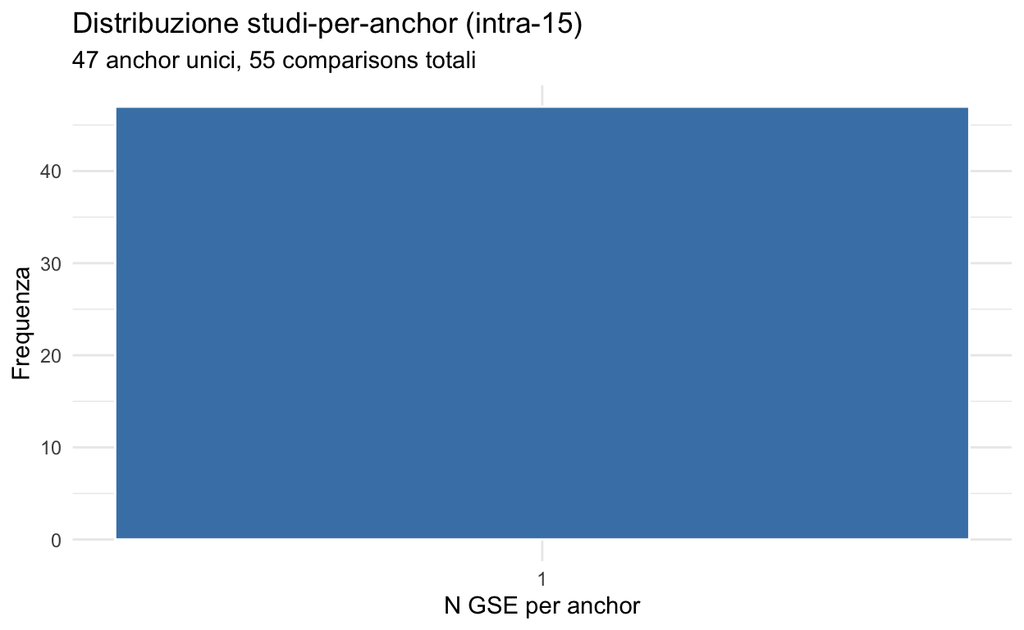

## 4. RummaGEO head-to-head

**Coverage:** 184 sample con label RummaGEO su 197 totali (93%). 197 con gold.

**RummaGEO vs gold:** accuracy = 69.6% (n = 184)

**simulomicsr vs gold:** accuracy = 75.1% (n = 197)

**simulomicsr vs RummaGEO** (agreement): 68.5% (n = 184)

**Delta:** simulomicsr batte RummaGEO di 5.6 punti percentuali.

### Source distribution (RummaGEO official vs internal fallback)

RummaGEO data source per sample

| Source | Count |
| --- | --- |
| internal_fallback_unavailable | 145 |
| rummageo_official | 39 |
| NA | 13 |

### Confusion matrix RummaGEO x gold

```
##          gold
## predicted control treated
##   control      30      19
##   treated      37      98
```

### McNemar test sui disagreement

McNemar test: chi^2 = 2.91, p = 0.0878

**P >= 0.05: differenza non significativa al test McNemar.**

### Per-design_kind: simulomicsr vs RummaGEO

Head-to-head per design_kind (delta = simulomicsr - rummageo, ordinato)

| design_kind | n | simulomicsr_acc | rummageo_acc | delta |
| --- | --- | --- | --- | --- |
| treatment_vs_vehicle | 8 | 1.000 | 0.500 | 0.500 |
| time_course | 21 | 1.000 | 0.714 | 0.286 |
| multi_arm_treatment | 85 | 0.706 | 0.635 | 0.071 |
| dose_response | 21 | 0.857 | 0.857 | 0.000 |
| factorial | 32 | 0.781 | 0.781 | 0.000 |
| knockdown_panel | 5 | 1.000 | 1.000 | 0.000 |
| treatment_vs_untreated | 12 | 0.417 | 0.583 | -0.167 |

## Conclusioni P3.5-B

**Prossimo step:** P3.5-A scaled benchmark su 50-100 GSE per evidenza paper-ready.